# Strings 2 – Extra Practice

Nathan Friedrichsen

There is very little new material needed for this lab. You may need to refer back to last week’s `Strings` lab as necessary. Feel free! Questions 1 and 2 should be doable, but not necessarily straight-forward. Question 3 introduces just a bit of `dplyr` applicability to the `stringr` and `lubridate` stuff.

```r
library(dplyr)
library(stringr)
library(lubridate)
library(ggplot2)
```

## Combining String Functions with `dplyr`

So far, we have primarily used functions from `stringr` to examine or modify individual character strings. However, these functions can also be used within `dplyr` to create new variables and summarize information across groups.

Consider a small dataset containing customer reviews for three different products:

```r
reviews = data.frame(
  Product = c("Laptop", "Laptop", "Laptop", "Laptop",
              "Headphones", "Headphones", "Headphones", "Headphones",
              "Keyboard", "Keyboard", "Keyboard", "Keyboard"),
  Review = c("Great laptop, great battery life",
             "Good performance but expensive",
             "Battery life is terrible",
             "Great value for the price",
             "Excellent sound quality",
             "Great sound but poor battery life",
             "Terrible fit and poor comfort",
             "Good headphones for the price",
             "Great keyboard and excellent keys",
             "Poor build quality",
             "Good value, great typing experience",
             "Terrible keyboard, poor quality")
)
```

Suppose we want to identify reviews containing positive words such as `"great"`, `"good"`, or `"excellent"`. We can use `str_detect()` inside `mutate()` to create a new logical variable:

```r
reviews |>
  mutate(Positive = str_detect(Review,
                              regex("great|good|excellent",
                                    ignore_case = TRUE)))
```

```
##       Product                              Review Positive
## 1      Laptop    Great laptop, great battery life     TRUE
## 2      Laptop      Good performance but expensive     TRUE
## 3      Laptop            Battery life is terrible    FALSE
## 4      Laptop           Great value for the price     TRUE
## 5  Headphones             Excellent sound quality     TRUE
## 6  Headphones   Great sound but poor battery life     TRUE
## 7  Headphones       Terrible fit and poor comfort    FALSE
## 8  Headphones       Good headphones for the price     TRUE
## 9    Keyboard   Great keyboard and excellent keys     TRUE
## 10   Keyboard                  Poor build quality    FALSE
## 11   Keyboard Good value, great typing experience     TRUE
## 12   Keyboard     Terrible keyboard, poor quality    FALSE
```

Recall that the `|` character in a regular expression allows us to match any of several alternatives. The `regex()` function allows us to ignore differences in capitalization.

The new `Positive` variable is `TRUE` whenever a review contains at least one of these words and `FALSE` otherwise.

We can also combine `str_detect()` with `group_by()` and `summarize()` to count the number of reviews containing these words for each product:

```r
reviews |>
  group_by(Product) |>
  summarize(PositiveReviews = sum(str_detect(
    Review, regex("great|good|excellent", ignore_case = TRUE)
  )))
```

```
## # A tibble: 3 × 2
##   Product    PositiveReviews
##   <chr>                <int>
## 1 Headphones               3
## 2 Keyboard                 2
## 3 Laptop                   3
```

Remember that R treats `TRUE` as 1 and `FALSE` as 0 when calculating sums. Consequently, `sum(str_detect(...))` counts the number of reviews containing at least one match within each group.

Similarly, taking the **mean of a logical variable** gives us the proportion of observations for which the condition is `TRUE`.

### Question 1

Using the `reviews` dataset, answer the following questions.

**Part A:** Create a new variable called `Negative` that identifies reviews containing either `"poor"` or `"terrible"`. Use this variable to filter the dataset to contain only *negative* reviews. Display the resulting dataset.

**Part B:** Using `group_by()` and `summarize()`, calculate the number of reviews containing either `"poor"` or `"terrible"` for each product.

**Part C:** Calculate the proportion of reviews containing either `"poor"` or `"terrible"` for each product. Which product has the highest proportion of negative reviews according to this definition? (Do not use your filtered dataset from Part A for this calculation)

## Driving Simulation Study

The data below comes from a real driving simulator experiment. The “disposition” file records the experimental participants, their assigned conditions, and the driving simulator output files that record a time-series of driver/vehicle inputs in a particular simulated drive. Output from the simulator are stored as DAQ file.

```r
disp = read.csv("https://NFriedrichsen.github.io/data/disposition.csv")
head(disp)
```

```
##   Analyze Reduced Ignore Discard                DaqPath
## 1               X             NA    Control\\C_001_POST
## 2               X             NA    Control\\C_002__PRE
## 3               X             NA    Control\\C_003__PRE
## 4               X             NA Occasional\\O_001__PRE
## 5               X             NA    Control\\C_004_POST
## 6               X             NA   Frequent\\F_001__PRE
##                              DaqName            Date
## 1 1_RuralRedLight_20180905113244.daq  9/5/2018 23:01
## 2 3_RuralRedLight_20180912092144.daq 9/12/2018 23:11
## 3 2_RuralRedLight_20180914094223.daq 9/14/2018 23:12
## 4 1_RuralRedLight_20180917093224.daq 9/17/2018 23:10
## 5 3_RuralRedLight_20180928135832.daq 9/28/2018 23:04
## 6 4_RuralRedLight_20181003103829.daq 10/3/2018 23:11
```

- The columns “Analyze”, “Reduced”, “Ignore” and “Discard” record how the researchers intend to handle certain DAQ files. Often problems arise during a simulated drive that prevent it from being useable. Only files with an “X” for reduced should be analyzed.
- The column “DaqPath” contains information about the driver, including:
  - Their group, either “Control”, “Occasional”, or “Frequent”
  - Their subject ID, a prefix of C/O/F followed by a three-digit number
  - Their experimental condition, either “PRE” for pre-dosing, or “POST” for post-dosing
- The column “DaqName” contains information about the drive, including:
  - The drive scenario, in this disposition file the two scenarios are “RuralRedLight” and “RedLight”
  - The order in which the participant experienced the stated scenario. For example, “1” means this was the first of four drives by that subject, “2” means it was the second of four drives by that subject, etc.
  - A time stamp for when the DAQ was recorded. For example, the first row’s DAQ was record on Sept 5th, 2018. The numbers following the date are specific to the simulator’s internal clock and generally not meaningful.

### Question 2

Exclude any drives that do not have an “X” in the reduced column. Then, using `stringr` functions as appropriate, process the information recorded in “disposition.csv” into a data frame with the following columns:

1. “Group” - either “Control”, “Occasional”, or “Frequent”
2. “SubjectID” - a string starting with “C”,” “O”, or “F” followed by an underscore and a 3-digit numeric identifier
3. “Treatment” - either “PRE” or “POST”
4. “Scenario” - either “RuralRedLight” or “RedLight”
5. “DriveNumber” - an integer between 1 and 4 indicating the ordering of the drive

*Hints*:

- Remember that the expression `\\\\` is needed to match a single `\`
- You may be find the expression `_[^\\d]*$` useful. Think about what it will will match.
- I recommend creating each constituent vector separately, then using `data.frame` to assemble them into a data frame.

Printed below are the first 10 rows of the target data.frame in the requested format.

```
##         Group SubjectID Treatment      Scenario DriveNumber
## 1     Control     C_001      POST RuralRedLight           1
## 2     Control     C_002       PRE RuralRedLight           3
## 3     Control     C_003       PRE RuralRedLight           2
## 4  Occasional     O_001       PRE RuralRedLight           1
## 5     Control     C_004      POST RuralRedLight           3
## 6    Frequent     F_001       PRE RuralRedLight           4
## 7    Frequent     F_002       PRE RuralRedLight           4
## 8     Control     C_005      POST RuralRedLight           3
## 9    Frequent     F_003       PRE RuralRedLight           4
## 10 Occasional     O_002       PRE RuralRedLight           1
```

$~$

## 2015 Boston Marathon Data

The [2015 Boston Marathon](https://en.wikipedia.org/wiki/2015_Boston_Marathon) took place on April 20th, 2015. It was the 119th running of one of the world’s most well-known races. The data below contain information, results, and splits for each finisher:

```r
marathon = read.csv("https://NFriedrichsen.github.io/data/BostonMarathon2015.csv")
```

The marathon data record running times as character strings in hours, minutes, and seconds. The `hms()` function from `lubridate` can convert these strings into time durations, which can then be used in calculations.

For example:

```r
time1 = hms("1:25:30")
time2 = hms("2:10:15")

time2 - time1
```

```
## [1] "1H -15M -15S"
```

```r
seconds(time1)
```

```
## [1] "5130S"
```

The `seconds()` function converts a duration into a numerical quantity measured in seconds. This will be useful when calculating running paces.

### Question 3

**Part A**: A marathon is approximately 26.2 miles, making the first half 13.1 miles. Using this information, calculate the per mile pace (in seconds) for each participant in the *first half of the race*. Be sure to store your results.

**Part B**: Now calculate the pace per mile in the *second half of the race*. Be sure to store your results.

**Part C**: **Challenge Question** (Not required, but I’ll think you’re cool if you can do it!) Now create a scatterplot displaying the relationship between pace per mile in the first half of the race vs. pace per mile in the second half of the race by age and sex. To facilitate this, you should assemble your results from Parts A and B into a data frame that also includes the “Age” and “M.F” columns from the original data. A target graphic is given below. *Note*: `scale_x_time()` and `scale_y_time()` can be used to display your first half and second half paces on a time scale. The graph shown below uses the argument `alpha = 0.2` to reduce the impact of over-plotting, and a 45-degree line is added using `geom_abline()`.

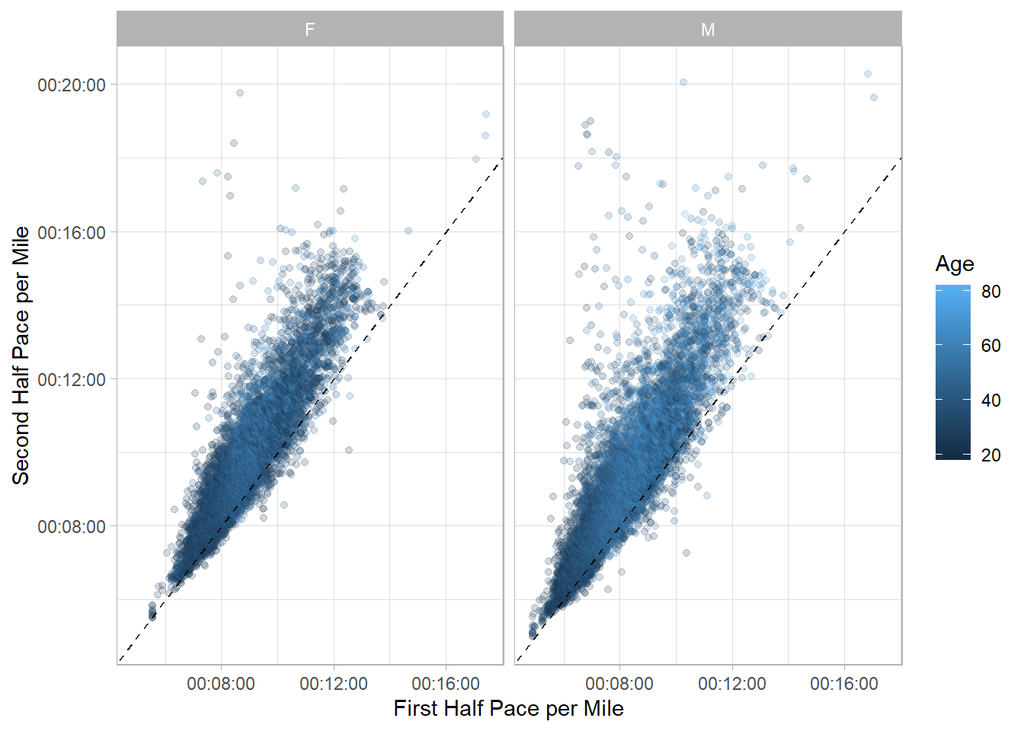